# BANA7030_FinalProject_Hodys

Ethan Hodys (M13603433)

April 24, 2020

## Final Project

### Project Description

Given the current situation of the pandemic, it was difficult to find a way to collect data safely for an actual problem during normal “life”. So instead I chose to collect data and model a problem I observed at the fast-food drive thru restaurants in my town. I wanted to provide evidence via modelling in Arena to justify the cost of implementating a second outdoor menu and ordering lane to improve drive thru efficiency.

I collected the observations below while monitoring the drive-thru lane at my local Wendy’s while sitting in my car in the parking lot (3802 Hamilton Cleves Rd, Hamilton, OH 45013). This is a single lane ordering, single menu, 2 service window restaurant that was operating only a single window for payment and food. The table below doesnt have any metadata for the observations that they were captured over a few different days for different time periods whenever I needed to leave to shope for essential goods.

```r
DT::datatable(observations)
```

|  | Col-1 | Col-2 | Col-3 | Col-4 | Col-5 | Col-6 | Col-7 | Col-8 | Col-9 |
| --- | --- | --- | --- | --- | --- | --- | --- | --- | --- |
| 1 | 0.890206216 | 2.845205269 | 4.365100318 | 3.53628894 | 1.336658383 | 3.101018657 | 0.424311352 | 5.598247739 | 0.711996464 |
| 2 | 5.35912311 | 3.814946952 | 1.089283411 | 0.130042315 | 1.488924543 | 1.15516082 | 1.845734526 | 1.086120133 | 3.511495032 |
| 3 | 4.181166671 | 0.509040336 | 0.646560902 | 0.908209089 | 4.32053973 | 1.794025666 | 1.756680414 | 0.479835087 | 2.778660143 |
| 4 | 0.797709428 | 0.483991749 | 3.884478914 | 3.468750404 | 0.721404453 | 1.841652831 | 0.942167941 | 0.315067349 | 2.698443243 |
| 5 | 2.434095141 | 1.552802019 | 7.348254028 | 1.088263559 | 2.454192945 | 1.422771681 | 6.186194269 | 1.415584872 | 6.422527289 |
| 6 | 1.705740434 | 0.863947086 | 1.773510002 | 4.997730683 | 2.283759359 | 1.041752854 | 1.926189144 | 2.50912989 | 0.583325989 |
| 7 | 4.920553369 | 0.831805872 | 5.169361535 | 0.955143901 | 1.205912834 | 2.379409399 | 2.426421849 | 2.863176835 | 0.167937073 |
| 8 | 1.734751993 | 0.293860879 | 1.638985867 | 2.008405493 | 5.434581219 | 2.246400978 | 2.992339032 | 0.292088221 | 1.153183925 |
| 9 | 1.230791457 | 2.758244015 | 0.48072823 | 2.326646842 | 1.402427265 | 2.349378548 | 2.189268581 | 0.554027059 | 3.326376597 |
| 10 | 1.898614199 | 1.222065148 | 1.763007186 | 0.897378071 | 0.299215248 | 1.085086102 | 3.5618452 | 0.469357851 | 1.29936009 |

[output cut: 2 more lines]

### Report

#### Abstract

**Primary Objective:** using real-world observations, create and simulate a model for detecting correctable inefficiencies for a typical American fast good restaurant. This is a proof-of-concept template as a basis for more rigorous future analysis and study.

**Secondary Objective:** Also to provide a framework for assisting others studying simulation techniques

**Simulation Software:** Arean Simulation Software: Free Community Edition (https://www.arenasimulation.com/)

**Assumptions & Weaknesses:** observations were performed over limited days and periods of the day for a single location for a single restaurant. Conclusions will have low accuracy and only apply this this single Wendy’s restaurant location at: 3802 Hamilton Cleves Rd, Hamilton, OH 45013

**Key Goals:**

1. Determine the average time in system
2. Determine average waiting time in queue

#### Analysis

**Process**

Below is a high level list of the arrival points that were taken in consideration:

1. Entity enters the system queue waiting at the intercom.
2. Wait time for Entity to place their order with live employee.
3. After order is completed proceeds to the live employee at the service window.
4. Entity waits at the service window
5. Entity exits the system

**Experimentation Setup**

As mentioned in the abstract, the real world system was observed to collect the necessary data for the purpos off creating a modelto be used in the *ARENA Simulation Software*

Model Entities identified :

- Cars

Variables:

- Quantity of order items
- Payment type
- Change given

Resources:

- Order Intercom
- Service Window

#### Results Summary

Unsurprisingly, the quantity of items ordered corresponded to amount of time spent the intercom and the service window.

Average time in system:

Average time waiting resources:

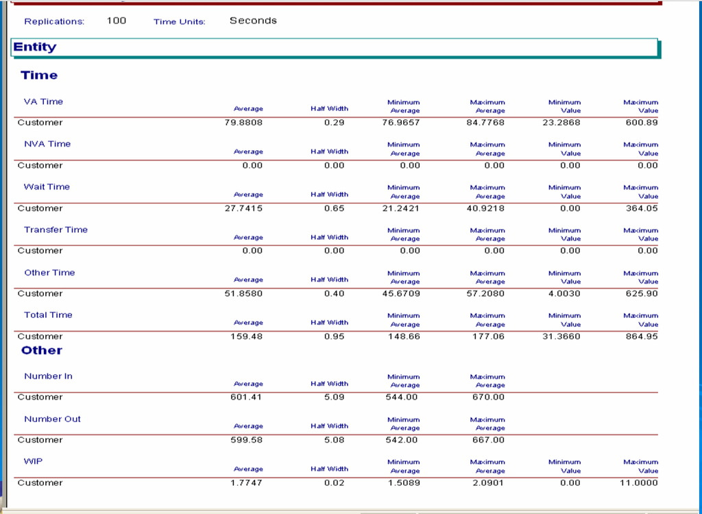

#### Recommendations

Associated Costs:

- Lower employee utilization at service windows
- Cost to construct new window and, potentially, second intercom and menu
- Net reduction in total time for a single order is only a matter of **seconds**

### Appendix

#### Arena Input Analysis

It is already known that drive thru windows follow a Poisson distributon and the Input Analyzer confirms this for my observations. A classification of Gamma or Weibull distribution is consistent.

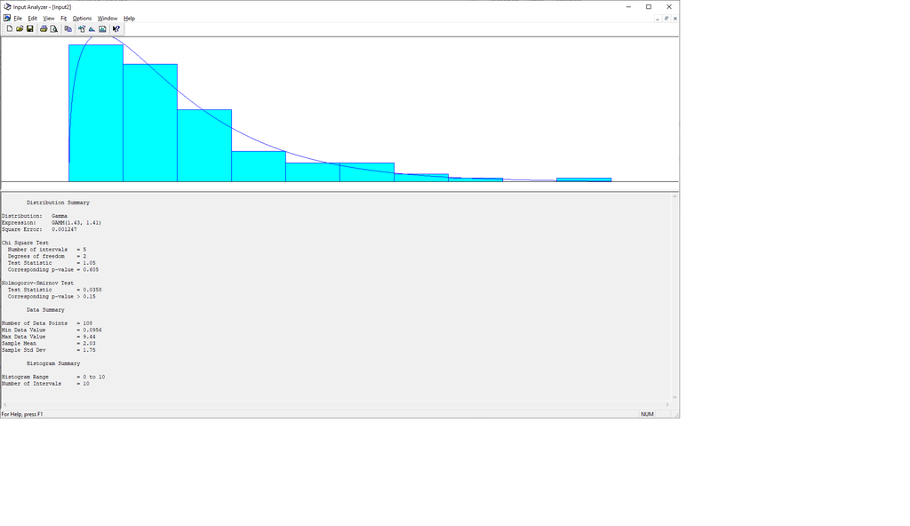

#### Arena Input Analysis Summary

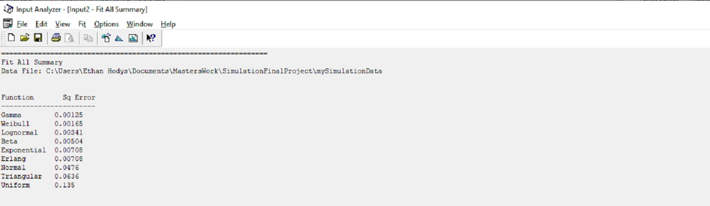

Analysis output shows the Gamma and Weibull distributions have the smallest squared error.

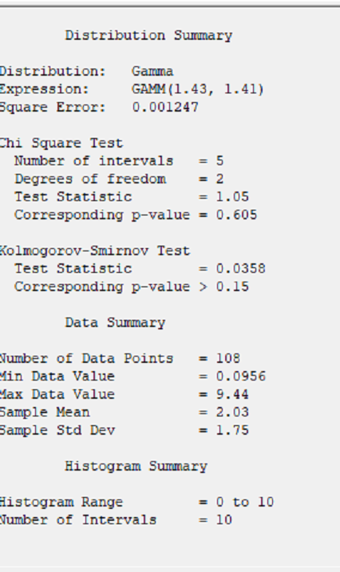

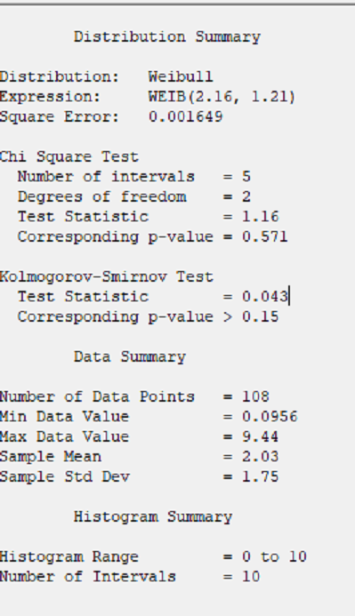

All p-values greater than .015. Gamma is slightly higher so it was chosen

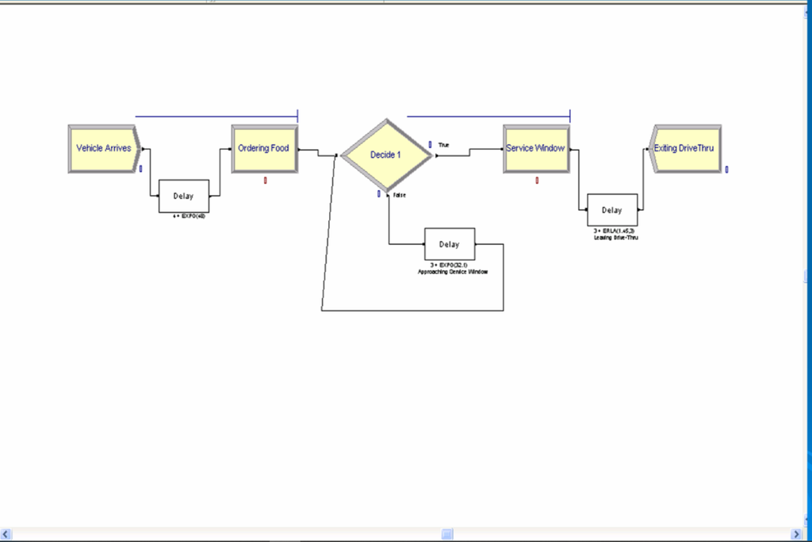

Process flow from Arena